[figure not shown]

Exploring the long term viability of

donor Schwann Cells in PEG fused

allografts

NEU 365N Term Paper

Akshat Patni

Ap46883

[figure not shown]

1

Abstract

Since the initial discovery regarding polyethylene glycol (PEG) as an effective membrane

fusogen, many potential clinical applications have been investigated. Researchers have

demonstrated that PEG fusion can be applied to lesions in the peripheral nervous system, repairing

transections as well as fusing allografts prior to the onset of Wallerian degeneration. PEG fused

allografts have exhibited an unusual phenomenon of immunotolerance despite existing in a non-

immune privileged environment in the PNS. This immunotolerance occurs even without the

administration of immunosuppressant drugs in laboratory subjects. Conventional PEG fused

allografts must be paired with systemic immunosuppression treatment or be sterilized of all cellular

elements except for the extracellular matrix in order to be viable. The mechanisms and

implications of this immunotolerance phenomenon in PEG fused allografts is not completely

understood. Current studies with viable PEG fused allografts do not examine the behavior of glial

cells over time. Specifically, it is unknown whether Schwann cell populations in the donor allograft

survive over the long term. Schwann cells are the primary glial cell of the PNS involved in

myelination of axons as well as mediating the immune response due to their expression of MHC II

proteins. That prompts the research question of this paper; Are donor Schwann cells viable over the

long term in PEG fused allografts or do they degrade over time and get replaced by local host

Schwann cells? In this study, we have designed an experiment in which viable sciatic nerve

sciatic nerve complexes were excised and digested by a solution of .05% type 1 collagenase. Each

sample was observed using phase contrast micrographs. When compared to a control group with

conventional sciatic nerve allografts, the experimental groups were evaluated for population sizes

of donor vs. host Schwann cells. This protocol demonstrates whether the donor Schwann cell

population survives in the allograft or if it gets slowly replaced by host Schwann cells. Results

showed that PEG fused allografts showed significantly increased survival rates for donor SC’s

when compared to the control group, confirming the hypothesis that PEG fusion of peripheral

nerve allografts lead to survival of donor SC populations. This observed difference between

conventional PNS allografts compared to PEG fused allografts lends credence to the notion that

host Schwann cells are linked to the immune rejection response in the peripheral nervous system.

This is supported by the fact that Schwann cells are antigen presenting cells that trigger T cell

activation and downstream signaling that leads to inflammation and macrophage activity.

[figure not shown]

2

Background

Schwann Cells

Study of the nervous system has shown how Schwann cells take on a diverse range of

functions in maintaining and supporting neurons in the PNS. As the primary type of glial cell in the

PNS, Schwann cells exist alongside axons in all types of peripheral nervous tissues, both motor

and sensory.

Origin of Schwann cells

During early embryonic development, the entirety of the nervous system as well as skin

tissue is derived from the outermost germ layer, the ectoderm. A monolayer of ectodermal cells

eventually forms the neural tube, and its intermediate region is known as the neural crest. The

neural crest eventually develops into the entire peripheral nervous system as well as most of the

autonomous nervous system. Neural crest tissue gives rise to a diverse range of cell types in the

early days of embryonic development, including the precursor cells of Schwann cells. These

precursor cells are developed at around E12-13 and are multipotent in their differentiation

capabilities. Other radial glial cells in the neural crest are also multipotent. The role of these

precursor cells is to proliferate heavily in the developing peripheral nervous system alongside other

precursor neuronal cells. This proliferation is induced by signaling cascades during the embryonic

development process, indicated by greatly increased levels of cAMP in the precursor cells. Notch

signaling is one of the primary signaling pathways responsible for Schwann cell precursor

proliferation during embryonic development. This is due to Notch receptors on glial cells activated

by Notch ligands on axons. Schwann cell precursors cannot survive outside of the presence of

neurons. At around E15-16, these precursor cells differentiate into immature Schwann cells. This

can be seen phenotypically with increased expression of Schwann cell specific proteins such as

MBP and S100 as well as morphological differences.

[14]

Immature Schwann cells undergo radial

sorting and are produced in a 1:1 ratio with large axons. At this stage of development, Schwann

cells can survive independently of neurons. Immature Schwann cells eventually differentiate into

various subtypes of mature Schwann cells, either myelinating or non-myelinating. These mature

Schwann cells maintain a high degree of plasticity, though they are not multipotent as the precursor

cells were.

[12]

There are two subtypes of Schwann cells, the myelinating subtype and non-myelinating

subtype. Myelinating Schwann cells play the role of wrapping around axons in the PNS to form the

myelin sheath. This is a crucial function performed in order to allow effective signal transduction

in the peripheral nervous system in both nervous and sensory neurons. The musculoskeletal system

relies on this function of Schwann cell derived myelination as it increases signal propagation speed

by one to two orders of magnitude, which is important for movement and sensation.

[26]

Myelinating

Schwann cells compromise the primary subtype of Schwann cell that exists in the peripheral

system.

[figure not shown]

3

Non-myelinating Schwann cells also play a significant role in the peripheral nervous system.

They are important for providing trophic support so that neurons can survive. They also assist in

the maintenance and repair of axons. One type of non-myelinating Schwann cell is the Remak

Schwann cell, which supports various unmyelinated axons in the PNS. Unmyelinated axons tend to

be smaller and exist in bundles, often in volatile environments such as the skin. The high plasticity

of Remak Schwann cells is important in the environment of the skin that is prone to constant

change and damage. Axons in the musculoskeletal system tend to be long and myelinated, though

they are supported by non-myelinating Schwann cells at the neuromuscular junction. Research

shows that these terminal Schwann cells help to form synaptic connections at these junctions.

[6]

While myelinating Schwann cells surround axons, non-myelinating Schwann cells are still located

in the nerve fascicle in the endoneurium.

One unique aspect of Schwann cells is that they are phenotypically unstable, unlike their CNS

glial cell counterparts (oligodendrocytes).

[14]

They are capable of undergoing phenotypic changes

and re-differentiating at any time to change their function, which is critical to the role they play in

peripheral nervous system repair. Schwann cells myelinate axons in a 1:1 ratio, whereas individual

oligodendrocytes myelinate several axons in the CNS. Another hallmark that distinguishes

Schwann cells from oligodendrocytes is the presence of basal lamina. Myelinated axons in the

CNS are bare at the nodes of Ranvier, whereas Schwann cells still surround the nodes in the

PNS.

[18]

Figure 1

[14]

Fig 1. Lineage of differentiation from neural crest to mature Schwann cells, phenotypic

plasticity is retained even at mature stage

Role as repair cells

After the onset of traumatic lesions in the peripheral nervous system, Schwann cells are the

principle support cells responsible for aiding repair and guiding axonal outgrowth. When axons are

transected and the distal segment loses connection with the cell body, the process of Wallerian

degeneration initiates cascades of signals within neurons and surrounding cells in the nerve

fascicle. The signaling environment of Schwann cells drastically changes as they lose connection

to the axon and proximal cell body. Molecules associated with an inflammatory response spread in

the surrounding environment, called DAMPs/PAMPs (damage/pathogen associated molecular

[figure not shown]

4

patterns). Schwann cells strongly express toll-like receptors that recognize these molecules,

signaling them to undergo major transcriptional changes. Normal Schwann cells become what is

referred to as “activated” Schwann cells through transdifferentiation. Both myelinating Schwann

cells and Remak Schwann cells differentiate into repair cells. Hundreds of genes are up-regulated

or down-regulated during this transdifferentiation process causing Schwann cells to phenotypically

transform. Morphologically, repair Schwann cells are much longer than regular Schwann cells. The

phenotype of repair Schwann cells is regulated by the H3K27 trimethylation mechanism.

[13]

Activated Schwann cells are partly responsible for helping clear cellular debris during

Wallerian degeneration as well as recruiting macrophages to do so, in an immune-like response.

[27]

They proliferate through cell division similar to how they did during embryonic development.

Activated Schwann cells also have significantly reduced transcription of myelinating proteins, and

also aid in the clearing of myelin debris.

Despite denervation, Schwann cells maintain basal lamina tubes known as ‘Bands of Bunger’.

Repurposed Schwann cells also secrete neurotrophins which help create an environment conducive

to growth for regrowing axons. Axonal outgrowth after transections is a slow process and often

lacks specificity due to misdirection. Bands of Bunger guide outgrowing axons towards the distal

stump and help preserve a specific and directional nature of growth until they form connections at

the neuromuscular junction. Outgrowing axons travel through these basal lamina tubes. Chronic

denervation causes significant atrophy of the target muscle which ultimately prevents synapses

from being re-established at the neuromuscular junction. This muscular atrophy can be delayed

through administration of electrical stimulation of muscle tissue. However, this treatment must be

administered periodically in order to delay atrophy and only lengthens the window temporarily.

This race against time is one of the biggest problems associated with PNS repair by natural axonal

outgrowth. The longer it takes, the greater the potential for poor, misdirected outgrowth and much

higher chances of atrophy at the neuromuscular junction. This leads to fairly poor outcomes in

terms of functional recovery.

[24]

Research has also demonstrated that chronic denervation has a

profound effect on the survival of Schwann cells. After a few months of denervation, only about

50% of repair Schwann cells survive. This hinders regeneration even further as outgrowing axons

rely heavily on support from Schwann cells to direct them and increase regeneration. Basal lamina

tubes degenerate over the long term, causing misdirection in axonal outgrowth. Thus, chronic

denervation creates a negative feedback loop which makes regeneration more and more difficult as

time goes on.

Immunogenic properties of Schwann Cells

Recent research on Schwann cells has revealed the significant role that they play in the

immune response in the peripheral nervous system. The immune function of Schwann cells

initiates during the ‘innate’ stage of the immune response, in response to DAMPs/PAMPs in the

environment of the endoneurium. These molecules are broadly associated with pathogens and

foreign microbial elements, or cellular damage. They trigger receptors that are expressed on

Schwann cells known as toll like receptors that cause Schwann cells to transdifferentiate into

“activated” repair Schwann cells. This is often triggered in cases of peripheral nervous system

damage, and corresponds to the role that Schwann cells play in Wallerian degeneration by

recruiting other immunogenic cells to clear cellular debris. Toll-like receptors are frequently

expressed on antigen presenting cells, supporting the immunocompetence of Schwann cells.

[28]

[figure not shown]

5

Schwann cells strongly express major histocompatibility complex (MHC) proteins,

specifically MHC II proteins. This is a major hallmark of antigen presenting cells. Antigen

presenting cells separate antigens into peptides and express them on the cytoplasmic surface

alongside MHC II proteins. This allows them to interact with T cell receptors.

[3]

MHC II proteins

are responsible for presenting antigens to immunogenic T cells to be recognized as foreign bodies

and activate the immune response. Schwann cells act as “nonprofessional antigen presenters” and

only take on that role for transient periods, unlike professional antigen presenting cells. The role of

Schwann cells in T cell activation is critical to recruiting all sorts of immunogenic cells such as

macrophages, neutrophils, etc. These cells play a significant role in consuming debris during

Wallerian degeneration or consuming any hostile foreign bodies in the nervous system such as

pathogens. The ability of the peripheral nervous system to clear debris is one of the reasons why it

is conducive to regeneration, unlike the environment of the CNS.

[13]

Unfortunately, certain

disorders can cause misrecognition of host nervous tissue as pathogenic and initiate an

autoimmune response that leads to degeneration of the peripheral nervous system. Guillain-Barré

syndrome is one such autoimmune disorder.

The immune response is thought to be self-regulating as inflammatory cells secrete

cytokines. Cytokines are agents that mediate the reaction of immunogenic cells, modulating the

communication between immune cells. This intercellular communication plays a significant role in

creating a negative feedback loop to prevent an uncontrolled cascade. Schwann cells are capable of

producing cytokines and other immunosuppressive mediators, as well as pro-inflammatory agents.

This suggests that they play a significant role in regulating the immune response in the peripheral

nervous system. Beyond mediation, Schwann cells can also trigger the completion of the immune

response by signaling T lymphocytes to undergo apoptosis through interactions between FAS

receptors on their cell surfaces.

[11]

Conventional Nerve Allografts

Purpose and usage

When axons or entire nerves get transected or ablated, the standard clinical practice is to

surgically attach the proximal and distal stumps together. Even though the distal stump will

undergo Wallerian degeneration, connecting the nerve ends helps to guide outgrowing axons

towards the neuromuscular junction. This marginally increases the specificity of regeneration by

outgrowth. Proximal and distal stumps are often aligned and connected together through

microsuture surgery, though research has shown that the administration of fibrin glue can be a

more effective method.

[1]

In a number of cases, it can be difficult for the proximal and distal ends

to meet together, even with administration of microsuture surgery. This is due to an uneven and

sizable gap between the nerve ends. This complication makes regeneration by axonal outgrowth

even more difficult due to misdirection and poor specificity. The nerve gap is often longer than the

ablated segment due to the retraction of both ends. The elastic nature of nerve fibers causes them to

retract when tension is disrupted due to transection or ablation. Researchers have tried to overcome

this complication by elongating the nerve segments at both ends in order to suture them together.

However, this is often ineffective due to the high traction forces at the suturing site.

[21]

To resolve

[figure not shown]

6

this issue, researchers have used a grafted nerve segment to ‘bridge’ the two ends together in order

to guide the outgrowing axons back towards the neuromuscular junction.

Types of Nerve Conduits

One option that has been used in clinical settings is a nerve autograft: a nerve segment

excised from within the subject’s own body and transplanted to the damaged region. This method

produces a number of complications. Excision of the autograft segment creates a neural deficit

elsewhere in the subject.

[22]

Additionally, if the nerve gap is long enough and large in diameter,

there is a lack of analogous nerve segments that can be excised from elsewhere in the subject

without creating excess morbidity. For these reasons, allografts have become a very popular option

in clinical settings. Allografts are nerve segments taken from another organism and transplanted

into the host subject. The biggest adverse consequence of using allografts over autografts is the

emergence of an immune response to foreign tissue in the host body.

Another option that has gained popularity is the use of commercially produced artificial

nerve conduits. These synthetic conduits have often been used in cases where an extensive amount

of nervous tissue has been ablated. If the size of the ablation and number of damaged nerves

exceeds the clinical threshold for the use of autografts, then synthetic grafts are favored. These

synthetic nerve conduits are often made of collagen to mimic the extracellular matrix of a real

nerve segment. Various synthetic nerve tubes have been approved by the FDA for lengths that

generally do not exceed ~3cm. This is due to the fact that synthetic nerve conduits lack Schwann

cells, trophic factors, and other supporting elements that help induce regeneration by outgrowth.

Researchers have made progress in the development of synthetic nerve tubes to increase the

effective maximum length beyond the previous 3cm limit. These efforts often involve harvesting

autologous Schwann cells to populate the synthetic nerve graft in order to aid regeneration of

axons.

[15]

Types of Allografts and Immune Rejection

Many researchers have performed studies to assess the most effective kind of allograft to

improve clinical nerve regeneration outcomes. One type of allograft is an unmodified cadaveric

allograft. Cadaveric allografts are simply excised from the donor subject and transplanted into the

subject, bridging the nerve gap. The advantage of this method is that the existing cellular mass in

the nerve graft is highly supportive of regeneration by outgrowth. This due to the presence of

viable Schwann cells and trophic factors that aid regrowing axons. Blood vessels are also key as

they provide transport for endothelial cells conducive to regeneration. However, the presence of

large quantities of foreign cells in this type of graft tissue triggers a severe immune response in the

host subject that can be fatal if the allograft tissue is significant in size. This requires the use of

systemic immunosuppression through medication to inhibit the immune response. Preservation of

allografts at cold temperatures can also help mitigate the immune response. Reduced temperatures

decrease the activity of immunogenic cells and decrease inflammation.

[30]

Another type of allograft used clinically is an acellular allograft. This type of allograft is

mostly sterilized. This means that most of the axonal cell mass, blood vessels, and other debris are

removed from the graft tissue. Glial cells such as Schwann cells are also removed. The only

[figure not shown]

7

remaining element is the extracellular matrix that acts as a skeletal structure for regenerating axons

to grow through. The advantage of this method is that it avoids major rejection from the immune

system and only elicits a minor immune response, due to the fact that all the cell mass is removed.

However, the disadvantage is that due to the lack of endogenous Schwann cells or trophic factors,

axonal regeneration through the graft is slow and limited compared to a cadaveric allograft. It takes

time for the host Schwann cells to populate the allograft matrix and period greatly delays

outgrowth. Due to this delay, acellular allografts are often limited to segments no more than 3cm

long, similar to synthetic nerve grafts.

[22]

There are few differences between an acellular nerve

allograft and a synthetic nerve conduit.

Different types of hybrids between the two main models of allografts have also been

studied. Scientists have found some success populating acellular allografts with vascular

endothelial growth factor, and Schwann cells.

[9]

Most of these models, however, used Schwann

cells taken from the host subject, due to the idea that donor Schwann cells would be rejected.

[7]

Using host Schwann cells helps regeneration by outgrowth to occur at an acceptable rate, whereas

the lack of Schwann cells and trophic factors would severely inhibit any outgrowth at all.

Behavior of donor Schwann Cells in conventional cadaveric allografts

Few studies have been conducted to observe and model the behavior of donor Schwann

cells in conventional allografts over the long term. This is due in part to the fact that most

commonly used clinical allografts are acellular allografts and not cadaveric allografts that come

with viable Schwann cells and supporting blood vessels. One such study by Midha et. al

thoroughly tested and observed the immune rejection of donor Schwann cells in sciatic nerve

allografts under different conditions of immunosuppression. This provides a basis of comparison

for further study of donor Schwann cell behavior when the allograft is PEG fused.

Study Methodology

Midha et. al modelled donor Schwann cell behavior using an animal model of Shiverer

mice, a strain of mice with a knockout mutation for myelin basic protein (MBP). MBP is expressed

in all wild type Schwann cells, and thus the knockout mutation gave them the ability to distinguish

between donor vs. host cells for the allografts in the study. After performing transplants of sciatic

nerve allografts they observed all the subjects over 14 weeks under various immunosuppressive

conditions. One of the most common immunosuppression drugs used in clinical tissue

transplantation is Cyclosporin A. It is highly bioavailable and can be administered orally, and does

not exhibit myelotoxicity.

[16]

One group was given continuous immunosuppression treatment via

Cyclosporin A. The other experimental group was given temporary CsA treatment for only 6

weeks. These two test groups were compared against a negative control group that received no

immunosuppression treatment.

After the observation periods, all subjects had the entire sciatic nerve complex excised and

analyzed with stains using immunohistochemistry against the primary antibody MCA 409. Any

tissue that was “positive” for the stain would indicate the presence of MBP, whereas negative

tissue would indicate a lack of MBP consistent with the donor Schwann cells of the knockout

Shiverer mice. Cross sections of the nerve segments were also stained with toluidine blue and

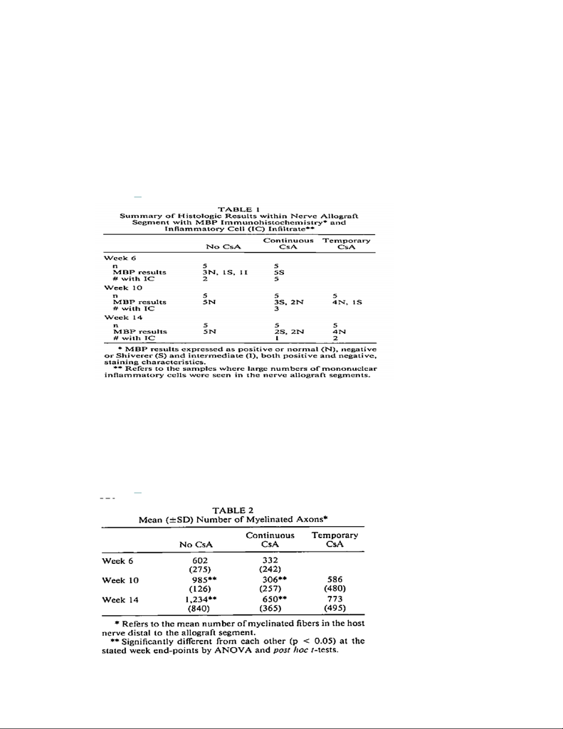

8

observed for morphometric features. The purpose of this was to observe the myelination of axons

distal to the transection site. The researchers assessed how immunosuppression affected the longer

term myelination of outgrowing axons. This is significant due to the fact that it reveals whether

host Schwann cells are largely responsible for myelination during outgrowth or if donor Schwann

cells also play a significant role.

Results

Figure 2

[19]

The histologic study demonstrated that with temporary or no immune suppression

treatment, donor Schwann cells in a cadaveric allograft eventually get replaced entirely by the host

Schwann cell population. Even with continuous immune suppression treatment, 50% of the donor

Schwann cell population gets replaced over 14 weeks and this likely continues past that point as

even a suppressed immune system detects and attacks the foreign tissue.

Figure 3

[19]

[figure not shown]

9

The morphometric study demonstrated a strange phenomenon: axons were re-myelinated

twice as much in the control group than the continuously suppressed experimental group. This

contradicts with the fact that immunosuppression treatment is necessary and beneficial when

cadaveric allografts are used. Researchers hypothesized that this was due to a sustained

inflammatory response given the fact that the foreign cells survived longer in the Continuous CsA

group. Host Schwann cells are likely to be active in expressing myelination proteins whereas donor

Schwann cells are likely inactive or ‘dormant’. Thus, repopulation of the graft with host Schwann

cells corresponds to an increase in myelination. Ultimately, immunosuppression treatment did not

guarantee donor Schwann cell survival over the long term but only delayed and elongated the

period of immune rejection. In this case, inflammation and a high presence of macrophages would

inhibit the rate of re-myelination.

[19]

Other research on cadaveric allografts

Studies on cadaveric PNS allografts in larger animal models such as sheep or pigs have

demonstrated less successful outcomes. Larger allografts induce a more pronounced immune

response and subsequently demand more potent immune suppression. Researchers identified

FK506 as a more effective immunosuppressant than Cyclosporin A for peripheral nerve allografts,

highlighted by decreased inflammation. However, in all conventional allografts, donor Schwann

cells are eventually replaced by host cells even with immunosuppression. This process of host

Schwann cell repopulation corresponds to regeneration of axons, suggesting that the presence of

host Schwann cells is necessary for outgrowth to effectively occur.

[17]

PEG Fused allografts

PEG fusion and change in allograft behavior

Polyethylene glycol (PEG) is a hydrophilic compound that is capable of acting as a cell

membrane fusogen. Researchers have applied PEG fusion to peripheral nerve injuries to fuse

proximal and distal nerve segments prior to the onset of Wallerian degeneration. Axonal continuity

remains preserved and nerve function is restored very quickly. This is a stark contrast to

regeneration by axonal outgrowth, in which axonal continuity is not maintained and the distal

stump undergoes Wallerian degeneration. The proximal end regenerates at a rate of no more than

2mm per day and ultimately takes months or even years to reach the neuromuscular junction in

larger mammals. This outgrowth is often accompanied with ample axonal misdirection and poor

functional recovery due to chronic denervation.

[2]

One complication of PEG fusion is that it fuses

membranes indiscriminately. This can create problems as different types of axons are fused

together without specificity.

[4]

For peripheral nerve allografts, PEG fusion can be used to fuse the graft segment to the

proximal and distal nerve ends and bridge the nerve gap. This process is also applied before the

onset of Wallerian degeneration, fundamentally changing the nature and behavior of the

allograft.

[5]

Conventional nerve allografts are only meant to act as a conduit for the outgrowing

axon to be guided through as the distal segment undergoes Wallerian degeneration; PEG fused

[figure not shown]

10

allografts retain full continuity of axons and signal transduction. The distal stump does not

degenerate.

Immunotolerance phenomenon

Research regarding PEG fused allografts is very recent and left with a multitude of

unanswered questions. One unexpected consequence of the application of PEG fusion to peripheral

nerve allografts is that PEG fused allografts are not rejected by the immune system. This is despite

the fact that the peripheral nervous system is not an immune privileged environment.

[20]

Various

areas of the body are immune privileged in order to avoid excessive inflammation that an

immunogenic environment produces. The eye is one example of such an environment.

[10]

It is an

exceedingly unique occurrence as almost all foreign cellular tissue introduced into a host organism

is recognized by both the innate and adaptive immune system and rejected. This is why almost all

organ transplants, including conventional nerve allografts, require the administration of

immunosuppression drugs to ensure clinical viability. Due to the fact that PEG fusion circumvents

the immune response in allografts, fully viable cadaveric allografts can be used with no

modification to the cell mass. This negates the need for acellular allografts that lack regeneration-

inducing elements such as Schwann cells and blood vessels. PEG fused allografts are also

fundamentally different from autografts or synthetic nerve conduits, as they maintain axonal

continuity. There is no upper limit to the length of the segment that can be used, nor is there an

added morbidity of having to create a neural deficit elsewhere in the clinical subject.

Studies observing the immunotolerance phenomenon have shown a number of different

observations of reduced immune activity, both innate and adaptive, in the environment of the PEG

fused allograft. The reduced expression of MHC II proteins indicates that there is no antigen

presentation activity occurring via Schwann cells, thus T cells would not be activated. Reduced T

cell infiltration confirms this and further evidence of the lack of immunogenic activity can be seen

with the reduced expression of cytokines. Most importantly, macrophages and other phagocytes do

not infiltrate the allograft tissue, as the primary immunogenic cells that consume foreign bodies or

debris. These observations demonstrate that no immune response takes place to reject the allograft

even though it is not tissue matched.

[25]

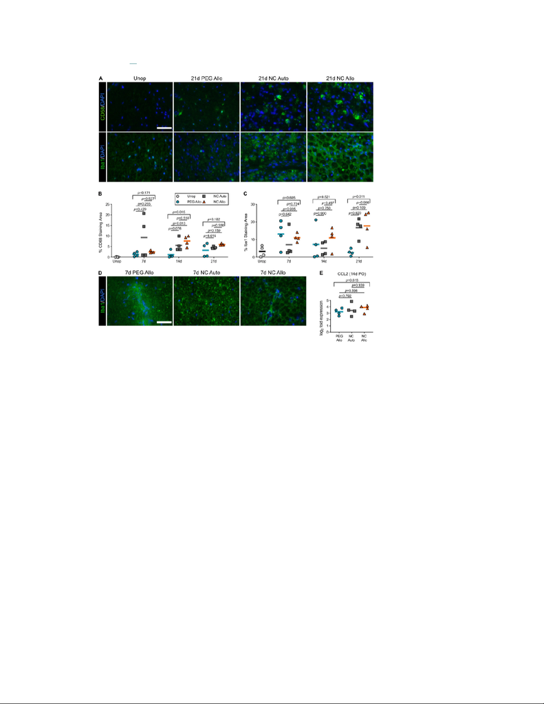

11

Figure 4

[25]

Fig 4. Reduced infiltration of macrophages seen in the PEG allograft 21 days p.o compared

to normal allograft. Key indicator of reduced immune activity due to lack of upstream signals

[figure not shown]

12

Experimental Design

Introduction

Current studies regarding PEG fused allografts have used fully viable allografts with cell

mass and found no immune rejection response. However, no long term studies were performed to

observe whether or not host Schwann cells repopulate the allograft tissue as one would see in

conventional allografts, replacing donor cells. That prompts the principle research question of this

study: Are donor Schwann cells viable over the long term in PEG fused allografts or do they get

replaced by local host Schwann cells? I hypothesize that host Schwann cells do not repopulate the

allograft segment and replace donor Schwann cells in PEG fused allografts.

Methods

Experimental Protocols

Test Group

Number of

Rats

Protocol

Sampling Time

Experimental

Group: PEG Fused

Allograft

sampling

period)

PEG fused allograft, excised

after observation period

1, 2, 4, 8, 14, 24 weeks

Positive Control:

Conventional

Allograft

sampling

period)

Conventional microsutured

allograft, excised after

observation period

1, 2, 4, 8, 14, 24 weeks

Experimental Model

This study will be conducted using an animal model to observe the behavior of donor and host

Schwann cells in a PEG fused allograft. The usage of an animal model is expected to have

sufficient predictive validity regarding the behavior of PEG fused allografts in a clinical setting in

larger mammals. The animal species to be used are two strains of rats, Wistar rats and Sprague-

Dawley rats. These are two common strains of rats used in laboratory research, particularly in

neurobiology studies. Literature has demonstrated that these two rat strains express phenotypic

differences in Schwann cells that can be distinguished through observations of cell morphologies.

These morphological differences are strongly accentuated by digestion of the nerve tissue in a

solution of 0.05% concentrated type 1 collagenase that isolates Schwann cells.

[29]

Wistar rat

Schwann cells transform drastically to show a round morphology after treated with type 1

collagenase while Sprague Dawley rats maintain an elongated, spindle morphology.

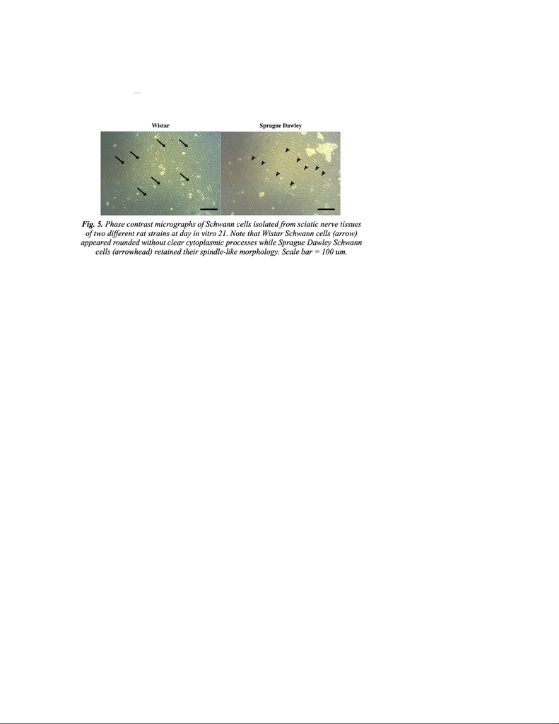

13

Figure 5

[29]

Experimental Groups

The study will consist of 1 broad experimental group of Sprague Dawley rats who receive a sciatic

nerve allograft from Wistar rats via PEG fusion. The negative control group will consist of Sprague

Dawley rats who receive a sciatic nerve allograft from Wistar rats via conventional microsuture

surgery. Both of the groups will receive a fully viable cadaveric allograft with Schwann cells,

blood vessels, and other nerve tissue. Neither group will undergo administration of

immunosuppression therapy. The experimental subgroups will segregate the rats that have the

allograft complex excised at different time intervals post implant: 1 week, 2 weeks, 4 weeks, 8

weeks, 14 weeks, and 24 weeks. This brings the total up to 12 test groups between the subjects

who receive PEG fused or conventional allografts.

Surgical Procedure

Wistar rats are not part of the in-vivo test group and thus will be euthanized in order to dissect and

extract a section of sciatic nerve tissue for allograft transplant. The live subject Sprague Dawley

rats will have an equal sized segment of sciatic nerve tissue excised to create the nerve gap to be

filled by the Wistar sciatic nerve allograft.

The extracted Wistar rat sciatic nerve segment will be transplanted into the sciatic nerve complex

of the Sprague Dawley subjects. In the control group, this allograft transplant will be executed

using conventional methods of microsuture surgery. In the experimental group, the allograft

transplant will be executed using PEG fusion methods. After both experimental groups receive

their respective allografts, they will not be subjected to immune suppression treatment in order to

see the full development of the innate immune response to each type of allograft. After the time

intervals have passed for each experimental subgroup (ranging from 1 – 24 weeks), the live

Sprague Dawley subjects will be euthanized. The entire sciatic nerve complex will be excised from

each subject for analysis.

[figure not shown]

14

Analytical procedure

After the sciatic nerve complex is excised from each subject, it will be preserved using

CO2. The sciatic nerve tissue will be digested through a solution of 0.05% (w/v) type 1 collagenase

and then observed for 14-21 days to see the morphological transformation of both donor and host

Schwann cell types in the allograft. At this point, the donor Wistar Schwann cell types will show a

circular morphology while the host Sprague Daley Schwann cell types will maintain spindle

morphology.

Using phase contrast microscopy, the isolated Schwann cells will be observed for each

experimental subgroup. Both types of Schwann cells will be counted using computer methods for

each sample, and then the ratio of donor vs. host Schwann cells will be calculated.

The quantitative results will be analyzed using a paired t-test at each time interval. This will

determine if the difference in survival of donor Schwann cells between the experimental and

control groups is statistically significant.

Results

Overview

The results of the study show that the ratio of donor/host Schwann cells remains relatively

stable all the PEG fused allograft subgroups. Donor Schwann cell populations did not change

significantly over the 24 weeks of observation, suggesting long term survival. In the control group,

the ratio of donor/host Schwann cells decreased dramatically over the first 8 weeks until only host

Schwann cells remained after the 14 week observation period.

The results of the paired t-test show that the difference in experimental conditions for both

test groups yields a statistically significant result, supporting the hypothesis. The donor to host

ratio was significantly different between the PEG fused allograft group and the conventional

allograft group on average.

Subjectively, the animals in the controlled group showed clear signs of an elevated immune

response. The excised sciatic nerve complexes from the control group showed high levels of

inflammation. The sciatic nerve complexes from the PEG fused allograft group did not show the

same visual signs of inflammation or immune rejection upon excision.

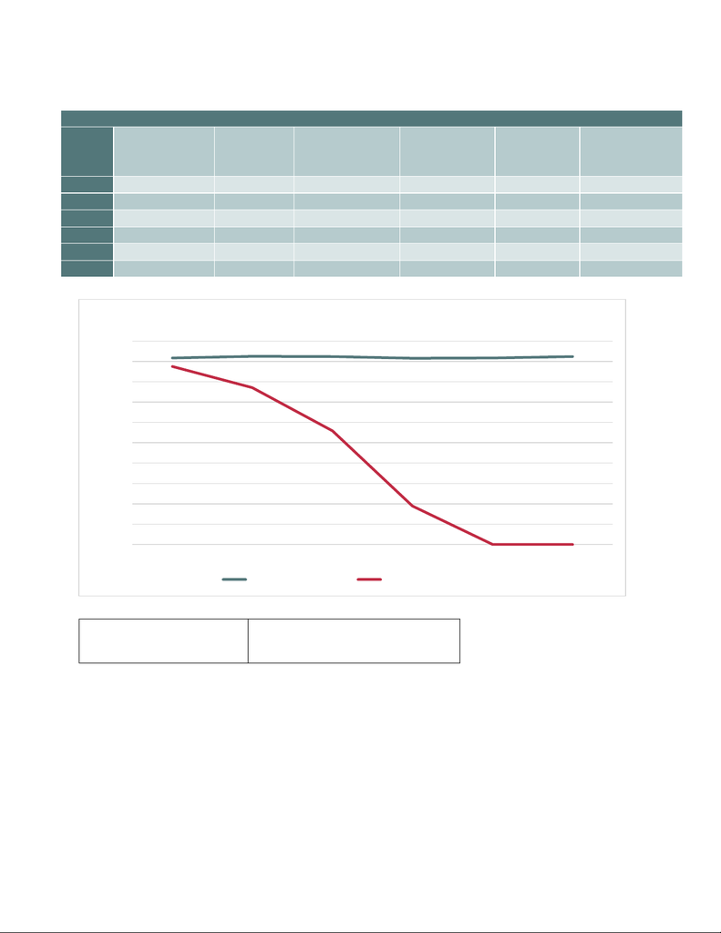

15

Figure 6

Average donor vs. host SC count by time interval

Mean PEG

donor SC

Count

Mean PEG

host SC

Count

PEG donor/host

ratio

Mean Control

donor SC

count

Mean

Control host

SC count

Control

donor/host ratio

Wk 1

121

132

.9166

112

128

.8750

Wk 2

123

133

.9248

101

131

.7710

Wk 4

122

132

.9242

77

138

.5580

Wk 8

119

130

.9154

29

153

.1895

Wk 14

120

131

.9160

0

172

.0000

Wk 24

121

131

.9237

0

212

.0000

Average paired t-

test p-value

.0081

0

0.1

0.2

0.3

0.4

0.5

0.6

0.7

0.8

0.9

1

Week 1 Week 2 Week 4 Week 8 Week 14 Week 24

Ratio of donor/host SC's

Ratio of donor/host Schwann cells

PEG donor/host ratio Control donor/host ratio

[figure not shown]

16

Discussion

The results of the study further reaffirm the phenomenon shown in prior research that PEG

fused allografts do not illicit an immune rejection response as seen in conventional allografts.

Furthermore, these results confirm the hypothesis that PEG fusion of peripheral nerve allografts

lead to the survival of donor Schwann cells. Host Schwann cells do not repopulate the allograft as

seen in conventional allografts.

This conforms with what we know about Schwann cells and the immune environment of

the peripheral nervous system. It has been demonstrated in many ways that Schwann cells are

immunogenically active, antigen presenting cells that heavily express MHC type II proteins. Since

PEG fused allografts restore axonal continuity, Wallerian degeneration does not occur and the

DAMP/PAMP molecules do not proliferate in the PNS environment. Toll like receptors on host

Schwann cells are not activated without the presence of these molecules, so the innate immune

response is not inherently triggered.

The results also suggest that the survival of donor Schwann cells also play a role in

‘escaping’ the adaptive immune response. Since donor Schwann cells survive in the allograft

segment, they recognize the tissue as endogenous and not foreign or hostile. This allows the

allograft segment to ‘escape’ the immune recognition from the host and avoid rejection, because

host Schwann cells do not populate the graft and process antigens to recognize it as foreign tissue.

Researchers have observed that host Schwann cell proliferation of a conventional allograft

is a precursor to axonal outgrowth. In previous studies, the onset of inflammatory response and

other symptoms of rejection coincided with the replacement of donor Schwann cells with host

Schwann cells. Axonal regeneration follows this repopulation of host Schwann cells.

[9]

Due to this,

it can be understood that there is a correspondence between the rejection response and proliferation

of host Schwann cells in allograft tissue. PEG fused allografts do not necessitate the proliferation

of host Schwann cells because regeneration of axons is completely bypassed. It is likely that donor

Schwann cells remain in the graft tissue and ‘hide’ the foreign tissue from the immune system in

the PNS. Other factors also mediate the immune response in peripheral nerves, but it is likely that

the lack of innate and adaptive immune response triggered in host Schwann cells plays a

significant role in inhibiting the rejection of PEG fused allograft tissue.

Alternative Results

If the results were to show that there is no statistically significant difference in the survival

of donor Schwann cells between the experimental group and the control group, it would invalidate

the hypothesis. This would contradict the theory that the survival of donor Schwann cells correlates

with the unexpected ability of PEG fused allografts to escape the immune response. Researchers

would have to hypothesize that there is some other unknown factor that distinguishes PEG fused

allografts from conventional allografts, causing the immunotolerance phenomenon.

[figure not shown]

17

References

1. Abulezz, T. (2012). Comparison between Conventional Microsuturing Technique and

Fibrin Glue in Repair of Peripheral Nerve Injuries. New Egyptian Journal of

Medicine.

2. Bittner, G., Sengelaub, D., Trevino, R., Peduzzi, J., Mikesh, M., Ghergherehchi, C., …

Thayer, W. (2015). The curious ability of polyethylene glycol fusion technologies to

restore lost behaviors after nerve severance. Journal of Neuroscience Research,

94(3), 207–230. https://doi.org/10.1002/jnr.23685

3. Cruse, J. M., Lewis, R. E. (R. E., & Wang, H. (2004). Antigen Presentation. In Immunology

guidebook (pp. 267–276). essay, Elsevier Academic Press.

4. Ghergherehchi, C. L., Hibbard, E. A., Mikesh, M., Bittner, G. D., & Sengelaub, D. R.

(2019). Behavioral recovery and spinal motoneuron remodeling after polyethylene

glycol fusion repair of singly cut and ablated sciatic nerves. Plos One, 14(10).

https://doi.org/10.1371/journal.pone.0223443

5. Ghergherehchi, C. L., Mikesh, M., Sengelaub, D. R., Jackson, D. M., Smith, T., Nguyen, J.,

… Bittner, G. D. (2019). Polyethylene glycol (PEG) and other bioactive solutions

with neurorrhaphy for rapid and dramatic repair of peripheral nerve lesions by PEG-

fusion. Journal of Neuroscience Methods, 314, 1–12.

https://doi.org/10.1016/j.jneumeth.2018.12.015

6. Griffin, J. W., & Thompson, W. J. (2008). Biology and pathology of nonmyelinating

Schwann cells. Glia, 56(14), 1518–1531. https://doi.org/10.1002/glia.20778

7. Gulati, A. K. (1995). Immunological Fate Of Schwann Cell-Populated Acellular Basal

Lamina Nerve Allografts. Transplantation, 59(11), 1618–1622.

https://doi.org/10.1097/00007890-199506000-00020

8. Hayashi, A., Moradzadeh, A., Tong, A., Wei, C., Tuffaha, S. H., Hunter, D. A., …

Myckatyn, T. M. (2008). Treatment modality affects allograft-derived Schwann cell

phenotype and myelinating capacity. Experimental Neurology, 212(2), 324–336.

https://doi.org/10.1016/j.expneurol.2008.04.018

9. Hoben, G., Yan, Y., Iyer, N., Newton, P., Hunter, D. A., Moore, A. M., … Mackinnon, S.

E. (2014). Comparison of Acellular Nerve Allograft Modification with Schwann

Cells or VEGF. Hand, 10(3), 396–402. https://doi.org/10.1007/s11552-014-9720-0

10. Hong, S., & Kaer, L. V. (1999). Immune Privilege: Keeping an Eye on Natural Killer T

Cells. Journal of Experimental Medicine.

11. Hörste, G. M. Z., Hu, W., Hartung, H.-P., Lehmann, H. C., & Kieseier, B. C. (2007). The

immunocompetence of Schwann cells. Muscle & Nerve, 37(1), 3–13.

https://doi.org/10.1002/mus.20893

12. Jessen, K. R., & Mirsky, R. (2019). Schwann Cell Precursors; Multipotent Glial Cells in

Embryonic Nerves. Frontiers in Molecular Neuroscience, 12.

https://doi.org/10.3389/fnmol.2019.00069

13. Jessen, K. R., & Mirsky, R. (2019). The Success and Failure of the Schwann Cell Response

to Nerve Injury. Frontiers in Cellular Neuroscience, 13.

https://doi.org/10.3389/fncel.2019.00033

18

14. Jessen, K. R., Mirsky, R., & Lloyd, A. C. (2015). Schwann Cells: Development and Role in

Nerve Repair. Cold Spring Harbor Perspectives in Biology, 7(7).

https://doi.org/10.1101/cshperspect.a020487

15. Kornfeld, T., Vogt, P. M., & Radtke, C. (2018). Nerve grafting for peripheral nerve injuries

with extended defect sizes. Wiener Medizinische Wochenschrift, 169(9-10), 240–

251. https://doi.org/10.1007/s10354-018-0675-6

16. Laupacis, A., Keown, P. A., & Ulan, R. A. (1982). Cyclosporin A: a powerful

immunosuppressant. Can Med Association.

17. Mackinnon, S. E., Doolabh, V. B., Novak, C. B., & Trulock, E. P. (2001). Clinical

Outcome following Nerve Allograft Transplantation. Plastic and Reconstructive

Surgery, 107(6), 1419–1429. https://doi.org/10.1097/00006534-200105000-00016

18. Martini, R., Groh, J., & Bartsch, U. (2010). Comparative biology of Schwann cells and

oligodendrocytes. The Biology of Oligodendrocytes, 19–48.

https://doi.org/10.1017/cbo9780511782121.003

19. Midha, R., Mackinnon, S. E., & Becker, L. E. (1994). The Fate of Schwann Cells in

Peripheral Nerve Allografts. Journal of Neuropathology and Experimental

Neurology, 53(3), 316–322. https://doi.org/10.1097/00005072-199405000-00013

20. Mikesh, M., Ghergherehchi, C. L., Rahesh, S., Jagannath, K., Ali, A., Sengelaub, D. R., …

Bittner, G. D. (2018). Polyethylene glycol treated allografts not tissue matched nor

immunosuppressed rapidly repair sciatic nerve gaps, maintain neuromuscular

functions, and restore voluntary behaviors in female rats. Journal of Neuroscience

Research, 96(7), 1243–1264. https://doi.org/10.1002/jnr.24227

21. Millesi, H. (1986). The nerve gap. Theory and clinical practice. Hand Clinics.

22. Moore, A. M., Macewan, M., Santosa, K. B., Chenard, K. E., Ray, W. Z., Hunter, D. A., …

Johnson, P. J. (2011). Acellular nerve allografts in peripheral nerve regeneration: A

comparative study. Muscle & Nerve, 44(2), 221–234.

https://doi.org/10.1002/mus.22033

23. Richardson, P., Mcguinness, U., & Aguayo, A. (1982). Peripheral nerve autografts to the

rat spinal cord: Studies with axonal tracing methods. Brain Research, 237(1), 147–

162. https://doi.org/10.1016/0006-8993(82)90563-7

24. Scheib, J., & Höke, A. (2013). Advances in Peripheral Nerve Regeneration. Nature

Reviews | Neurology.

25. Smith, T. A., Ghergherehchi, C. L., Mikesh, M., Shores, J. T., Tucker, H. O., & Bittner, G.

D. (2020). Polyethylene glycol‐fusion repair of sciatic allografts in female rats

achieves immunotolerance via attenuated innate and adaptive responses. Journal of

Neuroscience Research, 98(12), 2468–2495. https://doi.org/10.1002/jnr.24720

26. Susuki, K. (2010). Myelin: A Specialized Membrane for Cell Communication. Nature

Education.

27. Wei, Z., Fei, Y., Su, W., & Chen, G. (2019). Emerging Role of Schwann Cells in

Neuropathic Pain: Receptors, Glial Mediators and Myelination. Frontiers in

Cellular Neuroscience, 13. https://doi.org/10.3389/fncel.2019.00116

28. Ydens, E., Lornet, G., Smits, V., Goethals, S., Timmerman, V., & Janssens, S. (2013). The

neuroinflammatory role of Schwann cells in disease. Neurobiology of Disease, 55,

95–103. https://doi.org/10.1016/j.nbd.2013.03.005

29. Zaini, F. (2020). Wistar vs Sprague-Dawley: The Influence of Rat Strain on Schwann Cell

Isolation. Journal of Applied Biological Sciences.

19

30. Zalewski, A. A., Azzam, N. A., & Azzam, R. N. (1995). The Loss of Regenerated Host

Axons in Nerve Allografts after Stopping Immunosuppression with Cyclosporin A

Is Related to Immune Effects on Allogeneic Schwann Cells. Experimental

Neurology, 133(2), 189–197. https://doi.org/10.1006/exnr.1995.1021

[output not shown]